# RQ1 Step 1: Data understanding, cleaning and the processed dataset

What drives the real cost per m² of new houses across districts?

while True: learn(), Group 8, STAT462

2026-11-20

```r
source(file.path(proj_root, "R", "utils_data.R"))
library(knitr)

# ---- Settings for this notebook (change here, not further down) ------------
MIN_HOUSES   <- 5        # minimum new houses for a district-quarter to be modelled
TRAIN_LAST_Y <- 2019     # train = up to 2019Q4, test = 2020Q1 onwards (as pitched)
BASE_YQ      <- c(2026L, 2L)   # express real dollars in June-2026-quarter dollars
```

# 1 What this notebook does

**Research question 1 (slide 6 of the pitch):** *What drives the real cost per m² of new houses across districts?* Models are trained on district-quarters up to 2019 and tested on 2020–2026 (Step 3).

Before modelling we need a single, clean, **model-ready table** with:

- **One row per district × quarter** (67 territorial authorities, 1990Q2–2026Q2).
- **The response**: the *real* consented value per m² of new houses, so that a 1995 quarter and a 2025 quarter are measured in the same dollars.
- **Candidate drivers** (features) built from the consents data and placed alongside it.
- **Flags** for the train/test split and for rows too small to trust.

This notebook builds that table in nine steps, checking each one, and saves it to `data/processed/`. Every later RQ1 notebook (EDA, models) starts from the saved file instead of from the 757 MB raw CSV.

# 2 Which data do we need?

## 2.1 The 13 files in the consents release

The two Stats NZ zips gave us 13 CSVs. Only some of them matter for RQ1:

| File | Used for RQ1? | Why |
| --- | --- | --- |
| Building consents by **territorial authority** (Monthly) | **Yes, main source** | The only file with district-level houses: count, value and floor area. |
| New dwellings consented **per 1000 residents** by territorial authority (Annual) | **Yes, a feature** | How fast a district is building relative to its population. |
| Building consents by **region** (Quarterly) | **Yes, a check** | Lets us confirm our district → region mapping adds up. |
| Building consents by region (Monthly) | No | Same as the quarterly file at a finer grain; no district detail. |
| Building consents by Auckland local board (Monthly) | Not now | Only needed if we split Auckland into its 21 boards. |
| Building consents by institutional sector / control (Monthly) | No | National only, no geography. |
| New dwellings by 2023 / 2026 SA2 (Monthly) | Not now | Dwelling *counts* only: no value or floor area, so no $/m². |
| Per 1000 residents by region / Auckland local board | No | Region or board level only. |
| Non-residential outliers, NZ percentage change | No | National series. |

## 2.2 Data from outside the release

Consent values are **nominal** (in the dollars of the day) and **include GST**. To get a *real* cost we need a price index for building work. Stats NZ publishes one in a separate release:

- **Capital Goods Price Index (CGPI)**, *Business price indexes: June 2026 quarter*, quarterly, base Sep 2022 quarter = 1000. Downloaded into `data/raw/external/cgpi/` from the Stats NZ release page (CSV zip). Two candidate series:
  - `CEPQ.S611011A`: **Dwelling units** (closest match to new houses)
  - `CEPQ.S61101`: Residential buildings (all residential)
  - We also keep `CEPQ.S61102`, Non-residential buildings, to deflate the non-residential feature.

Nothing else is needed for a first model. Optional extras for later, if time allows: district house-price indices, land values, or population estimates.

# 3 Load the territorial authority table

The TA file is long-format (one row per *series × month*), 4.35 million rows. We read it with `data.table::fread`, which takes seconds rather than minutes.

```r
ta_raw <- read_infoshare("Building consents by territorial authority (Monthly).csv",
                         keep_status = TRUE)
dim(ta_raw)
```

```
## [1] 4348384       9
```

```r
ta_raw |> count(Status, name = "rows") |> kable(caption = "Row status")
```

Row status

| Status | rows |
| --- | --- |
| F | 4348384 |

**Observation.** 4,348,384 rows; every one has status `F` (final), so none of the values we use will be revised in a later release.

## 3.1 Keep only the series RQ1 needs

There are 26 nested building types × 3 kinds of work × 3 measures. We take just the series we need and give each one a short variable name. Because the building types are **nested** (houses are inside dwelling units, which are inside residential buildings, …) we never add across them.

```r
series_map <- tribble(
  ~var,             ~btype,                                          ~work,     ~measure,
  "houses_n",       "Houses",                                        "New",     "Number",
  "houses_m2",      "Houses",                                        "New",     "Floor area",
  "houses_val",     "Houses",                                        "New",     "Value",
  "dwell_n",        "Dwelling units",                                "New",     "Number",
  "apt_n",          "Apartments",                                    "New",     "Number",
  "retire_n",       "Retirement village units",                      "New",     "Number",
  "town_n",         "Townhouses, flats, units, and other dwellings", "New",     "Number",
  "resid_new_val",  "Residential buildings",                         "New",     "Value",
  "resid_alt_val",  "Residential buildings",                         "Altered", "Value",
  "nonres_new_val", "Non-residential buildings",                     "New",     "Value"
)
kable(series_map, caption = "Series taken from the TA file")
```

Series taken from the TA file

| var | btype | work | measure |
| --- | --- | --- | --- |
| houses_n | Houses | New | Number |
| houses_m2 | Houses | New | Floor area |
| houses_val | Houses | New | Value |
| dwell_n | Dwelling units | New | Number |
| apt_n | Apartments | New | Number |
| retire_n | Retirement village units | New | Number |
| town_n | Townhouses, flats, units, and other dwellings | New | Number |
| resid_new_val | Residential buildings | New | Value |
| resid_alt_val | Residential buildings | Altered | Value |
| nonres_new_val | Non-residential buildings | New | Value |

```r
ta_month <- ta_raw |>
  inner_join(series_map, by = c("btype", "work", "measure")) |>
  select(area, period, var, value) |>
  pivot_wider(names_from = var, values_from = value)

rm(ta_raw); invisible(gc())
dim(ta_month)
```

```
## [1] 30453    12
```

## 3.2 Check 1 — is the grid complete?

After pivoting, a missing series would show up as `NA`. We look at the 68 sub-national areas (67 TAs + “Area Outside Territorial Authority”) from April 1990.

```r
sub_nat <- ta_month |> filter(area != "New Zealand")

tibble(
  areas          = n_distinct(sub_nat$area),
  first_month    = min(sub_nat$period),
  last_month     = max(sub_nat$period),
  months         = n_distinct(sub_nat$period),
  rows           = nrow(sub_nat),
  expected_rows  = n_distinct(sub_nat$area) * n_distinct(sub_nat$period),
  missing_values = sum(is.na(sub_nat |> select(-area, -period)))
) |> kable()
```

| areas | first_month | last_month | months | rows | expected_rows | missing_values |
| --- | --- | --- | --- | --- | --- | --- |
| 68 | 1990.04 | 2026.08 | 437 | 29716 | 29716 | 0 |

**Observation.** The grid is complete: every area has every month from 1990.04 to 2026.08 and no value is missing. Zeros are real zeros (no houses consented that month), not gaps.

## 3.3 Check 2 — does the building-type hierarchy add up?

Dwelling units should equal houses + apartments + retirement units + townhouses/flats. Stats NZ rounds, so we allow a difference of 1.

```r
sub_nat |>
  mutate(diff = dwell_n - (houses_n + apt_n + retire_n + town_n)) |>
  summarise(rows_checked = n(),
            rows_off_by_more_than_1 = sum(abs(diff) > 1),
            max_abs_diff = max(abs(diff))) |>
  kable()
```

| rows_checked | rows_off_by_more_than_1 | max_abs_diff |
| --- | --- | --- |
| 29716 | 0 | 0 |

## 3.4 Check 3 — do districts add up to New Zealand?

```r
sum_check <- sub_nat |>
  group_by(period) |>
  summarise(across(c(houses_n, houses_m2, houses_val), sum), .groups = "drop") |>
  inner_join(ta_month |> filter(area == "New Zealand") |>
               select(period, nz_n = houses_n, nz_m2 = houses_m2, nz_val = houses_val),
             by = "period")

sum_check |>
  summarise(months = n(),
            count_mismatch = sum(abs(houses_n - nz_n) > 1),
            m2_mismatch    = sum(abs(houses_m2 - nz_m2) > 1),
            value_mismatch = sum(abs(houses_val - nz_val) > 1000)) |>
  kable()
```

| months | count_mismatch | m2_mismatch | value_mismatch |
| --- | --- | --- | --- |
| 437 | 0 | 0 | 0 |

**Observation.** Both checks are exact: dwelling units equal the sum of their four sub-types in every district-month, and the districts (plus the area outside any TA) add up to the New Zealand total for count, floor area and value in all 437 months. The file is internally consistent, so we can use the house series as published without repairing anything.

# 4 Monthly → quarterly district frame

Monthly district figures are noisy: a small district may consent 3 houses one month and none the next. Following the pitch, the unit of analysis is the **district-quarter**. We:

1. drop the national total and the “Area Outside Territorial Authority”,
2. sum the three months of each quarter (sums of counts, $ and m², *not* averages of ratios), and
3. keep only **complete** quarters (all 3 months present), which removes the partial 2026Q3 (Jul–Aug).

```r
ta_q <- sub_nat |>
  filter(area != "Area Outside Territorial Authority") |>
  mutate(year    = period_year(period),
         quarter = month_quarter(period_month(period))) |>
  group_by(ta = area, year, quarter) |>
  summarise(months = n(),
            across(all_of(series_map$var), sum),
            .groups = "drop") |>
  filter(months == 3) |>
  select(-months) |>
  mutate(yq = yq_label(year, quarter), t_index = yq_index(year, quarter)) |>
  arrange(ta, t_index)

tibble(districts = n_distinct(ta_q$ta),
       quarters  = n_distinct(ta_q$yq),
       first     = min(ta_q$yq), last = max(ta_q$yq),
       rows      = nrow(ta_q)) |> kable(caption = "The district-quarter frame")
```

The district-quarter frame

| districts | quarters | first | last | rows |
| --- | --- | --- | --- | --- |
| 67 | 145 | 1990Q2 | 2026Q2 | 9715 |

**Observation.** 67 districts × 145 quarters = 9,715 rows, matching the 9,715 in the pitch.

# 5 Add region and island

```r
concord <- read_csv(file.path(paths$reference, "ta_region_concordance.csv"),
                    show_col_types = FALSE)

# every TA in the data must be in the lookup, and vice versa
stopifnot(setequal(concord$ta, unique(ta_q$ta)))

ta_q <- ta_q |> left_join(concord, by = "ta")
concord |> count(region, name = "districts") |> arrange(desc(districts)) |> kable()
```

| region | districts |
| --- | --- |
| Waikato Region | 10 |
| Canterbury Region | 9 |
| Wellington Region | 8 |
| Manawatu-Whanganui Region | 7 |
| Bay of Plenty Region | 6 |
| Otago Region | 5 |
| Hawke’s Bay Region | 4 |
| Northland Region | 3 |
| Southland Region | 3 |
| Taranaki Region | 3 |
| West Coast Region | 3 |
| Area Outside Region | 1 |
| Auckland Region | 1 |
| Gisborne Region | 1 |
| Marlborough Region | 1 |
| Nelson Region | 1 |
| Tasman Region | 1 |

## 5.1 Check 4 — do our district sums reproduce the regional file?

The regional quarterly file is compiled from the *true* geography of each consent, so a district that straddles a regional boundary (e.g. Taupō, Waitaki, Tararua, Rangitīkei) will create small differences. Large differences would mean a district is in the wrong region.

```r
reg_q <- read_infoshare("Building consents by region (Quarterly).csv") |>
  filter(btype == "Houses", work == "New", measure == "Number", adjust == "Actual") |>
  transmute(region = area,
            year = period_year(period),
            quarter = month_quarter(period_month(period)),
            reg_houses_n = value)

region_check <- ta_q |>
  group_by(region, year, quarter) |>
  summarise(our_houses_n = sum(houses_n), .groups = "drop") |>
  inner_join(reg_q, by = c("region", "year", "quarter")) |>
  group_by(region) |>
  summarise(quarters       = n(),
            our_total      = sum(our_houses_n),
            file_total     = sum(reg_houses_n),
            pct_difference = 100 * (our_total - file_total) / file_total,
            .groups = "drop") |>
  arrange(desc(abs(pct_difference)))

save_tab(region_check, "t01_region_check") |> kable(digits = 2,
  caption = "New houses 1990-2026: sum of our districts vs the regional file")
```

New houses 1990-2026: sum of our districts vs the regional file

| region | quarters | our_total | file_total | pct_difference |
| --- | --- | --- | --- | --- |
| Otago Region | 145 | 35347 | 34894 | 1.30 |
| Bay of Plenty Region | 145 | 53423 | 53016 | 0.77 |
| Waikato Region | 145 | 78338 | 78737 | -0.51 |
| Canterbury Region | 145 | 114201 | 114654 | -0.40 |
| Taranaki Region | 145 | 12922 | 12916 | 0.05 |
| Hawke’s Bay Region | 145 | 16366 | 16373 | -0.04 |
| Manawatu-Whanganui Region | 145 | 25311 | 25318 | -0.03 |
| Auckland Region | 145 | 182305 | 182305 | 0.00 |
| Gisborne Region | 145 | 2981 | 2981 | 0.00 |
| Marlborough Region | 145 | 9255 | 9255 | 0.00 |
| Nelson Region | 145 | 6710 | 6710 | 0.00 |
| Northland Region | 145 | 31889 | 31889 | 0.00 |
| Southland Region | 145 | 8706 | 8706 | 0.00 |
| Tasman Region | 145 | 11971 | 11971 | 0.00 |
| Wellington Region | 145 | 41730 | 41730 | 0.00 |
| West Coast Region | 145 | 5033 | 5033 | 0.00 |

# 6 From nominal to real $/m²

## 6.1 The price index

```r
cgpi <- fread(file.path(paths$raw_cgpi, "business-price-indexes-june-2026-csv.csv"),
              select = c("Series_reference", "Period", "Data_value"),
              colClasses = list(character = "Period")) |>
  as_tibble() |>
  filter(Series_reference %in% c("CEPQ.S611011A", "CEPQ.S61101", "CEPQ.S61102")) |>
  mutate(year = period_year(Period), quarter = month_quarter(period_month(Period))) |>
  select(series = Series_reference, year, quarter, index = Data_value) |>
  pivot_wider(names_from = series, values_from = index) |>
  rename(cgpi_dwell = `CEPQ.S611011A`, cgpi_resid = `CEPQ.S61101`,
         cgpi_nonres = `CEPQ.S61102`) |>
  arrange(year, quarter)

# one row per quarter, and our whole frame is covered
stopifnot(!anyDuplicated(cgpi[c("year", "quarter")]))
missing_q <- anti_join(distinct(ta_q, year, quarter), drop_na(cgpi), by = c("year", "quarter"))
nrow(missing_q)   # should be 0
```

```
## [1] 0
```

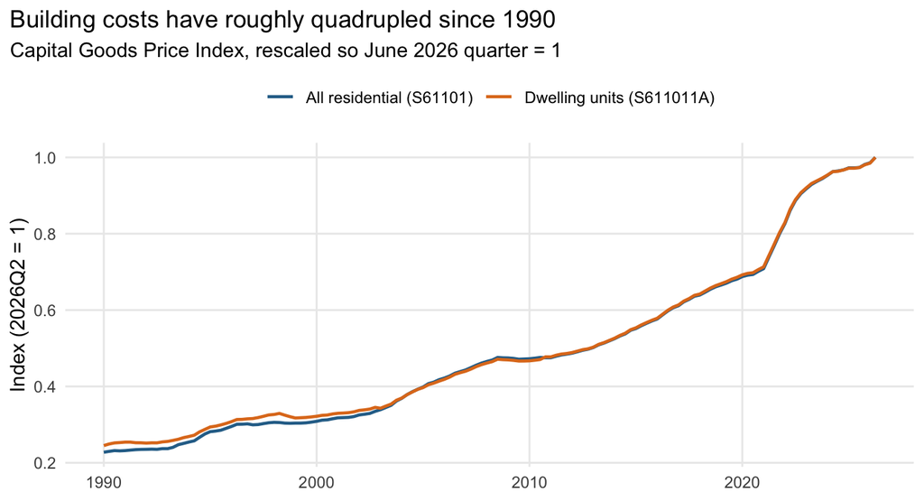

```r
base <- cgpi |> filter(year == BASE_YQ[1], quarter == BASE_YQ[2])

p_cgpi <- cgpi |>
  filter(year >= 1990) |>
  mutate(date = year + (quarter - 1) / 4,
         `Dwelling units (S611011A)`        = cgpi_dwell / base$cgpi_dwell,
         `All residential (S61101)`         = cgpi_resid / base$cgpi_resid) |>
  pivot_longer(c(`Dwelling units (S611011A)`, `All residential (S61101)`),
               names_to = "series", values_to = "index") |>
  ggplot(aes(date, index, colour = series)) +
  geom_line(linewidth = 0.8) +
  scale_colour_manual(values = c("#2a6f97", "#e07a1f")) +
  labs(title = "Building costs have roughly quadrupled since 1990",
       subtitle = "Capital Goods Price Index, rescaled so June 2026 quarter = 1",
       x = NULL, y = "Index (2026Q2 = 1)", colour = NULL) +
  theme(legend.position = "top")
save_fig(p_cgpi, "fig01_cgpi")
```

```r
cor(cgpi$cgpi_dwell, cgpi$cgpi_resid, use = "complete.obs")
```

```
## [1] 0.9995751
```

**Decision.** We use **Dwelling units** (`CEPQ.S611011A`), because it prices the type of building in our response. The two series are almost identical, so this choice will barely change the results.

## 6.2 GST

Consent values **include GST**, and GST rose from **12.5% to 15% on 1 October 2010**. Without a correction, every district’s $/m² jumps by 1.15 / 1.125 = **+2.2%** in 2010Q4 for a purely tax reason. We therefore:

1. remove the GST of the day: `value / (1 + GST rate at the time)`,
2. deflate with the CGPI to June-2026-quarter prices, and
3. add back today’s 15% GST, so the numbers stay comparable to the GST-inclusive figures in the pitch.

$$\text{real_cost_m2} = \frac{\text{value}}{\text{floor area}} \times
\frac{1}{1+\text{GST}_t} \times
\frac{\text{CGPI}_{2026Q2}}{\text{CGPI}_t} \times 1.15$$

```r
ta_q <- ta_q |>
  left_join(cgpi, by = c("year", "quarter")) |>
  mutate(
    gst          = gst_rate(year, quarter),
    real_factor  = (1.15 / (1 + gst)) * (base$cgpi_dwell / cgpi_dwell),
    nominal_cost_m2 = if_else(houses_m2 > 0, houses_val / houses_m2, NA_real_),
    real_cost_m2    = nominal_cost_m2 * real_factor,
    # real values of the other $ series (non-residential uses its own index)
    resid_alt_val_real  = resid_alt_val  * real_factor,
    nonres_new_val_real = nonres_new_val * (1.15 / (1 + gst)) * (base$cgpi_nonres / cgpi_nonres)
  )
```

## 6.3 Sanity check against the pitch

The pitch said national new-house $/m² went up ×4.7 in nominal terms between 1991 and 2025, but only about +14% in real terms. We recompute the national series from our districts.

```r
nz_year <- ta_q |>
  group_by(year) |>
  filter(n_distinct(quarter) == 4) |>
  summarise(nominal = sum(houses_val) / sum(houses_m2),
            real    = sum(houses_val * real_factor) / sum(houses_m2),
            houses  = sum(houses_n),
            avg_m2  = sum(houses_m2) / sum(houses_n), .groups = "drop")
invisible(save_tab(nz_year, "t02_nz_annual_cost_m2"))

nz_year |> filter(year %in% c(1991, 2000, 2010, 2019, 2025)) |>
  mutate(year = as.character(year)) |>
  kable(digits = 0, format.args = list(big.mark = ","),
        caption = "New Zealand new houses: $/m² (real = June-2026 dollars, GST 15%)")
```

New Zealand new houses: $/m² (real = June-2026 dollars, GST 15%)

| year | nominal | real | houses | avg_m2 |
| --- | --- | --- | --- | --- |
| 1991 | 681 | 2,749 | 12,380 | 153 |
| 2000 | 835 | 2,628 | 15,394 | 192 |
| 2010 | 1,391 | 3,006 | 13,066 | 216 |
| 2019 | 2,217 | 3,271 | 22,269 | 194 |
| 2025 | 3,226 | 3,311 | 16,635 | 178 |

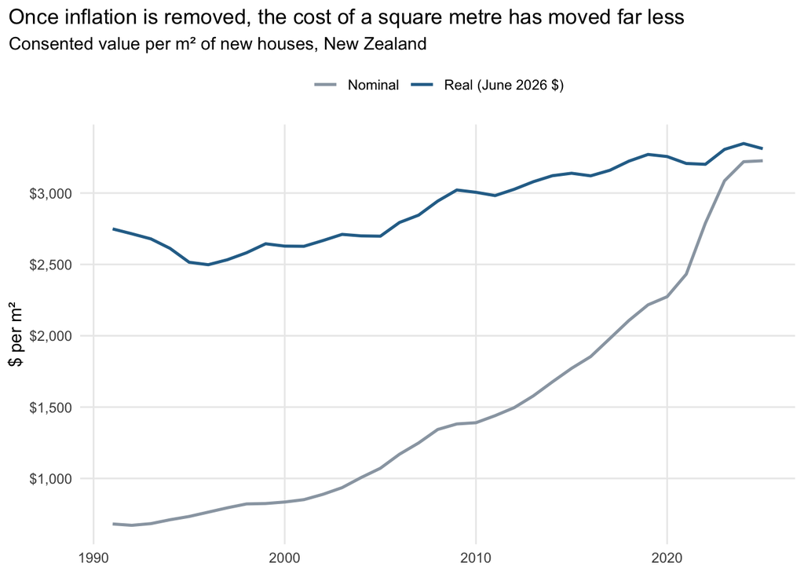

```r
p_nz <- nz_year |>
  pivot_longer(c(nominal, real), names_to = "basis", values_to = "cost_m2") |>
  ggplot(aes(year, cost_m2, colour = basis)) +
  geom_line(linewidth = 0.9) +
  scale_colour_manual(values = c(nominal = "#9aa5b1", real = "#2a6f97"),
                      labels = c("Nominal", "Real (June 2026 $)")) +
  scale_y_continuous(labels = scales::dollar) +
  labs(title = "Once inflation is removed, the cost of a square metre has moved far less",
       subtitle = "Consented value per m² of new houses, New Zealand",
       x = NULL, y = "$ per m²", colour = NULL) +
  theme(legend.position = "top")
save_fig(p_nz, "fig02_nz_nominal_vs_real")
```

**Observation.** Nominal growth 1991→2025: ×4.74. Real growth: 20.5%. Most of the headline increase is general building-cost inflation. In real terms the cost per m² fell slightly through the early 1990s, then rose fairly steadily from 1996 to about 2019 and has been roughly flat since.

# 7 Features: candidate drivers of cost

Each feature is computed per district-quarter. We avoid any feature built from **house value**, because value is the numerator of the response and would leak the answer into the predictors.

| Feature | Meaning | Why it might drive cost |
| --- | --- | --- |
| `avg_house_m2` | floor area ÷ number of new houses | Bigger houses spread fixed costs (kitchen, bathrooms, consenting) over more m² |
| `log_houses_n` | log of new houses consented | Scale: builders in busy markets may be cheaper (or demand pushes prices up) |
| `multiunit_share` | share of new dwellings that are *not* stand-alone houses | Urban density / land scarcity |
| `retire_share`, `apt_share` | retirement-village / apartment share of new dwellings | Market type |
| `dwell_per_1000` | new dwellings in the 12 months to this quarter per 1,000 residents | Building intensity relative to population (from 1996 only) |
| `houses_yoy` | log change in houses vs the same quarter last year | Demand pressure / boom-bust |
| `log_resid_alt_real`, `log_nonres_real` | real value of residential alterations / new non-residential work | Overall construction activity competing for builders |
| `region`, `island`, `is_city`, `ta` | location | Land, transport, labour and climate (e.g. insulation rules) differ by place |
| `year`, `quarter`, `t_index` | time | Trend and seasonality left after deflating |
| `real_cost_m2_lag1`, `_lag4` | the district’s own cost last quarter / a year ago | Persistence; only for a *forecasting* version of the model |

```r
per1000 <- read_infoshare("New dwellings consented per 1000 residents by territorial authority (Annual).csv") |>
  mutate(year = period_year(period), month = period_month(period)) |>
  filter(month %in% c(3, 6, 9, 12), area != "New Zealand") |>   # year ending at each quarter-end month
  transmute(ta = area, year, quarter = as.integer(month / 3), dwell_per_1000 = value)

stopifnot(!anyDuplicated(per1000[c("ta", "year", "quarter")]))
setdiff(unique(per1000$ta), unique(ta_q$ta))   # names should all match (expect none)
```

```
## character(0)
```

```r
rq1 <- ta_q |>
  left_join(per1000, by = c("ta", "year", "quarter")) |>
  group_by(ta) |>
  arrange(t_index, .by_group = TRUE) |>
  mutate(
    avg_house_m2    = if_else(houses_n > 0, houses_m2 / houses_n, NA_real_),
    log_houses_n    = log(pmax(houses_n, 1)),
    multiunit_share = if_else(dwell_n > 0, 1 - houses_n / dwell_n, NA_real_),
    apt_share       = if_else(dwell_n > 0, apt_n / dwell_n, NA_real_),
    retire_share    = if_else(dwell_n > 0, retire_n / dwell_n, NA_real_),
    houses_yoy      = log((houses_n + 1) / (lag(houses_n, 4) + 1)),
    log_resid_alt_real = log1p(resid_alt_val_real),
    log_nonres_real    = log1p(nonres_new_val_real),
    # lagged response: only trusted when that quarter also had enough houses
    real_cost_m2_lag1 = if_else(lag(houses_n, 1) >= MIN_HOUSES, lag(real_cost_m2, 1), NA_real_),
    real_cost_m2_lag4 = if_else(lag(houses_n, 4) >= MIN_HOUSES, lag(real_cost_m2, 4), NA_real_)
  ) |>
  ungroup() |>
  mutate(is_city   = str_detect(ta, " City$") | ta == "Auckland",
         log_real_cost_m2 = log(real_cost_m2))
```

**Observation.** Lags and the year-on-year change are computed **before** any rows are filtered out, so a lag always refers to the true previous quarter rather than the previous *kept* row.

## 7.1 Relative cost: each district compared with the rest of New Zealand

This response was added after the Step 2 EDA showed that time explains about 40% of the variation in real cost, and that 2020–2026 costs sit well above the training years.

RQ1 asks about differences **across districts**. A cleaner response for that question is a district’s cost **relative to the rest of the country in the same quarter**:

$$\text{rel_log_cost_m2} = \log(\text{district real \$/m}^2) -
\log(\text{real \$/m}^2 \text{ of all other districts, same quarter})$$

A value of +0.10 means “about 10% dearer than the rest of NZ that quarter”. The national level is computed **leave-one-out** (excluding the district itself). Otherwise Auckland, which has up to 40% of all houses in some quarters, would partly be compared with itself. We do the same for house size (`rel_house_m2`).

```r
nat_q <- rq1 |>
  group_by(yq) |>
  summarise(nat_val_real = sum(houses_val * real_factor),
            nat_m2 = sum(houses_m2), nat_n = sum(houses_n), .groups = "drop")

rq1 <- rq1 |>
  left_join(nat_q, by = "yq") |>
  mutate(
    loo_cost_m2     = (nat_val_real - houses_val * real_factor) / (nat_m2 - houses_m2),
    loo_house_m2    = (nat_m2 - houses_m2) / (nat_n - houses_n),
    rel_log_cost_m2 = log_real_cost_m2 - log(loo_cost_m2),
    rel_house_m2    = log(avg_house_m2 / loo_house_m2)
  ) |>
  select(-nat_val_real, -nat_m2, -nat_n)

rq1 |> filter(houses_n >= MIN_HOUSES) |>
  summarise(mean_rel = mean(rel_log_cost_m2), sd_rel = sd(rel_log_cost_m2),
            sd_abs = sd(log_real_cost_m2)) |> kable(digits = 3)
```

| mean_rel | sd_rel | sd_abs |
| --- | --- | --- |
| -0.036 | 0.114 | 0.152 |

**Observation.** We keep **both** responses. `log_real_cost_m2` asks *“how expensive, in real terms?”*, which mixes national time effects with district effects. `rel_log_cost_m2` asks *“how much dearer or cheaper than the rest of NZ at the same time?”*, which isolates the district effect that RQ1 is about. Step 2 compares them.

# 8 Data quality: small counts and outliers

## 8.1 How many houses are behind each row?

```r
rq1 |>
  summarise(rows = n(),
            zero_houses     = sum(houses_n == 0),
            under_5         = sum(houses_n < 5),
            under_10        = sum(houses_n < 10),
            median_houses   = median(houses_n)) |>
  kable(caption = "District-quarters by number of new houses")
```

District-quarters by number of new houses

| rows | zero_houses | under_5 | under_10 | median_houses |
| --- | --- | --- | --- | --- |
| 9715 | 215 | 1053 | 2272 | 28 |

```r
rq1 |>
  group_by(ta) |>
  summarise(median_houses = median(houses_n),
            share_under_min = mean(houses_n < MIN_HOUSES), .groups = "drop") |>
  arrange(median_houses) |> head(10) |>
  kable(digits = 2, caption = "The ten smallest districts")
```

The ten smallest districts

| ta | median_houses | share_under_min |
| --- | --- | --- |
| Chatham Islands Territory | 0 | 0.99 |
| Kawerau District | 0 | 0.98 |
| Wairoa District | 3 | 0.80 |
| Waitomo District | 4 | 0.51 |
| Stratford District | 5 | 0.43 |
| Waimate District | 5 | 0.49 |
| Gore District | 6 | 0.35 |
| Opotiki District | 6 | 0.28 |
| Rangitikei District | 6 | 0.32 |
| Kaikoura District | 7 | 0.27 |

## 8.2 Ratios from few houses are noisy

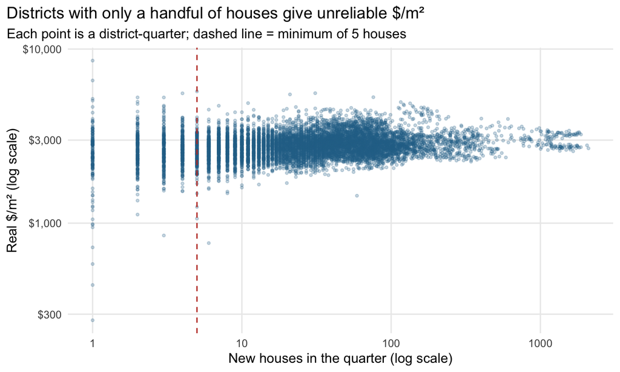

```r
p_funnel <- rq1 |>
  filter(houses_n > 0) |>
  ggplot(aes(houses_n, real_cost_m2)) +
  geom_point(alpha = 0.25, size = 0.8, colour = "#2a6f97") +
  geom_vline(xintercept = MIN_HOUSES, linetype = 2, colour = "#c0392b") +
  scale_x_log10() +
  scale_y_log10(labels = scales::label_dollar(accuracy = 1)) +
  labs(title = "Districts with only a handful of houses give unreliable $/m²",
       subtitle = paste0("Each point is a district-quarter; dashed line = minimum of ",
                         MIN_HOUSES, " houses"),
       x = "New houses in the quarter (log scale)",
       y = "Real $/m² (log scale)")
save_fig(p_funnel, "fig03_funnel_small_counts")
```

**Observation.** The spread narrows as the number of houses grows (a “funnel”). Below about 5 houses a single unusual consent (a tiny cabin, a luxury build) dominates the quarter. We keep these rows in the full file but **exclude rows with fewer than 5 houses from modelling**. A sensitivity check with 10 can be run later by changing `MIN_HOUSES` at the top.

## 8.3 Extreme values that remain

```r
kept <- rq1 |> filter(houses_n >= MIN_HOUSES)

bind_rows(
  kept |> slice_max(real_cost_m2, n = 5) |> mutate(end = "highest"),
  kept |> slice_min(real_cost_m2, n = 5) |> mutate(end = "lowest")
) |>
  select(end, ta, yq, houses_n, avg_house_m2, nominal_cost_m2, real_cost_m2) |>
  kable(digits = 0, caption = "Most extreme real $/m² among modelled rows")
```

Most extreme real $/m² among modelled rows

| end | ta | yq | houses_n | avg_house_m2 | nominal_cost_m2 | real_cost_m2 |
| --- | --- | --- | --- | --- | --- | --- |
| highest | Opotiki District | 2024Q1 | 5 | 187 | 5449 | 5713 |
| highest | Wellington City | 2025Q1 | 31 | 174 | 5420 | 5579 |
| highest | Gisborne District | 2025Q2 | 21 | 127 | 5333 | 5489 |
| highest | Whangarei District | 2011Q1 | 76 | 214 | 2525 | 5291 |
| highest | Queenstown-Lakes District | 2025Q1 | 116 | 215 | 4819 | 4960 |
| lowest | Opotiki District | 1995Q3 | 6 | 86 | 225 | 768 |
| lowest | Wairoa District | 1995Q3 | 5 | 61 | 311 | 1062 |
| lowest | Kaikoura District | 1993Q1 | 5 | 176 | 310 | 1239 |
| lowest | Waimakariri District | 1991Q4 | 59 | 342 | 355 | 1437 |
| lowest | Waimate District | 1991Q3 | 5 | 189 | 366 | 1480 |

```r
quantile(kept$real_cost_m2, c(0, .01, .05, .25, .5, .75, .95, .99, 1)) |> round(0)
```

```
##   0%   1%   5%  25%  50%  75%  95%  99% 100%
##  768 1983 2211 2539 2801 3078 3620 4153 5713
```

## 8.4 Shape of the response

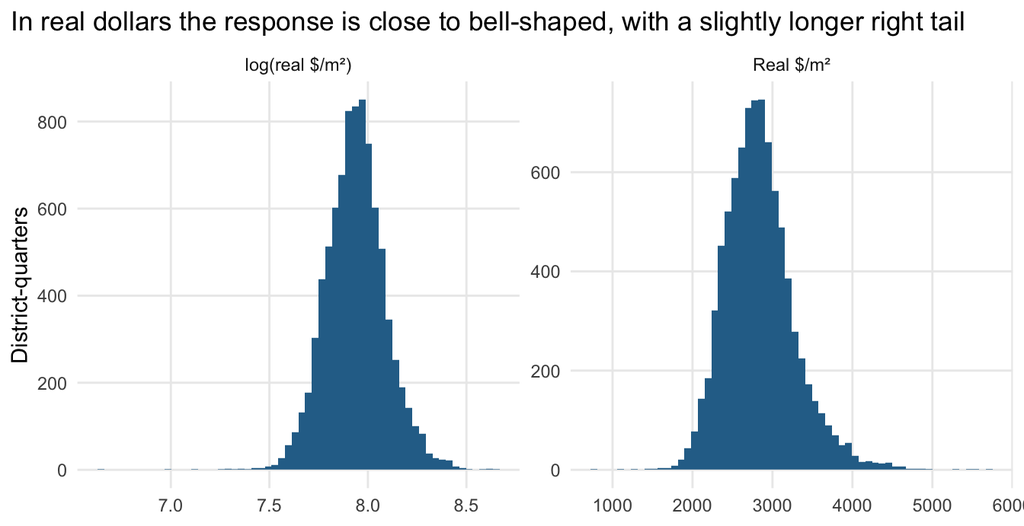

```r
p_resp <- kept |>
  select(`Real $/m²` = real_cost_m2, `log(real $/m²)` = log_real_cost_m2) |>
  pivot_longer(everything()) |>
  ggplot(aes(value)) +
  geom_histogram(bins = 60, fill = "#2a6f97") +
  facet_wrap(~ name, scales = "free") +
  labs(title = "In real dollars the response is close to bell-shaped, with a slightly longer right tail",
       x = NULL, y = "District-quarters")
save_fig(p_resp, "fig04_response_distribution", height = 3.4)
```

**Observation.** Once inflation is removed, most of the skew disappears: the middle 98% of modelled rows lie between about $2,000 and $4,150 per m² (median about $2,800), with a slightly longer right tail and a few very low quarters from small districts in the early 1990s. Nominal dollars would have been strongly skewed, because they mix the price levels of different decades.

We will still model **`log(real $/m²)`** as the main response, because (i) effects of drivers on cost are naturally multiplicative (“10% more expensive”), so coefficients read as percentage effects, and (ii) it tames the remaining tails slightly. Trees and random forests don’t need this, but using the same response for every model keeps the comparison fair. Both versions are saved, so we can check in Step 3 whether it matters.

# 9 Train / test split

The split is **by time**, not random. All districts move together with the national building cycle, so a random split would put quarters from the same year in both sets and make the test score look better than it is.

```r
rq1 <- rq1 |>
  mutate(split    = if_else(year <= TRAIN_LAST_Y, "train", "test"),
         in_model = houses_n >= MIN_HOUSES & !is.na(real_cost_m2))

split_tab <- rq1 |>
  group_by(split) |>
  summarise(period = paste(min(yq), "to", max(yq)),
            all_rows = n(),
            modelled_rows = sum(in_model),
            districts_modelled = n_distinct(ta[in_model]), .groups = "drop") |>
  arrange(desc(split))
save_tab(split_tab, "t03_split_sizes") |> kable(caption = "Train/test split")
```

Train/test split

| split | period | all_rows | modelled_rows | districts_modelled |
| --- | --- | --- | --- | --- |
| train | 1990Q2 to 2019Q4 | 7973 | 7051 | 67 |
| test | 2020Q1 to 2026Q2 | 1742 | 1611 | 67 |

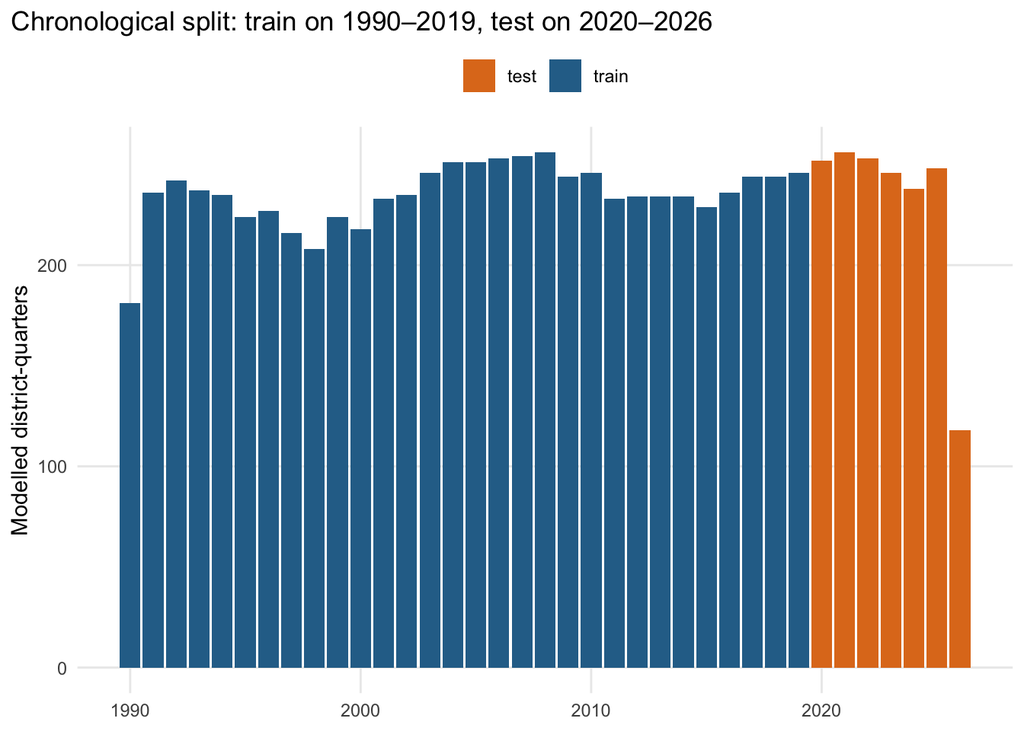

```r
p_split <- rq1 |>
  filter(in_model) |>
  count(year, split) |>
  ggplot(aes(year, n, fill = split)) +
  geom_col() +
  scale_fill_manual(values = c(train = "#2a6f97", test = "#e07a1f")) +
  labs(title = "Chronological split: train on 1990–2019, test on 2020–2026",
       x = NULL, y = "Modelled district-quarters", fill = NULL) +
  theme(legend.position = "top")
save_fig(p_split, "fig05_train_test_split", height = 3.4)
```

**Observation.** The pitch’s 7,973 / 1,742 counts were for *all* district-quarters; after dropping rows with fewer than 5 houses the modelled counts are those in the table above. 2026 has only two quarters, and `dwell_per_1000` starts in 1996, so the earliest training years will have that feature missing.

# 10 Save the processed data

```r
dir.create(paths$processed, showWarnings = FALSE, recursive = TRUE)

col_order <- c(
  # keys
  "ta", "region", "island", "is_city", "year", "quarter", "yq", "t_index", "split", "in_model",
  # response
  "real_cost_m2", "log_real_cost_m2", "rel_log_cost_m2", "nominal_cost_m2",
  # raw quantities
  "houses_n", "houses_m2", "houses_val", "dwell_n", "apt_n", "retire_n", "town_n",
  "resid_new_val", "resid_alt_val", "nonres_new_val",
  # features
  "avg_house_m2", "rel_house_m2", "log_houses_n", "multiunit_share", "apt_share", "retire_share",
  "dwell_per_1000", "houses_yoy", "log_resid_alt_real", "log_nonres_real",
  "real_cost_m2_lag1", "real_cost_m2_lag4",
  # deflators
  "gst", "cgpi_dwell", "cgpi_resid", "cgpi_nonres", "real_factor", "loo_cost_m2", "loo_house_m2"
)
rq1 <- rq1 |> select(all_of(col_order))

# full frame (all 9,715 district-quarters, with flags)
write_csv(rq1, file.path(paths$processed, "rq1_district_quarter_full.csv"))

# model-ready rows only, as CSV (for anyone) and RDS (keeps factor types for R)
rq1_model <- rq1 |>
  filter(in_model) |>
  mutate(across(c(ta, region, island, split), factor),
         quarter = factor(quarter))
write_csv(rq1_model, file.path(paths$processed, "rq1_model_data.csv"))
saveRDS(rq1_model,  file.path(paths$processed, "rq1_model_data.rds"))

list.files(paths$processed)
```

```
## [1] "rq1_data_dictionary.csv"       "rq1_district_quarter_full.csv"
## [3] "rq1_model_data.csv"            "rq1_model_data.rds"
## [5] "rq2_district_features.csv"     "rq2_district_features.rds"
## [7] "rq3_model_data.csv"            "rq3_model_data.rds"
```

```r
dim(rq1); dim(rq1_model)
```

```
## [1] 9715   43
```

```
## [1] 8662   43
```

## 10.1 Data dictionary

```r
dictionary <- tribble(
  ~column, ~description,
  "ta", "Territorial authority (district / city), as named by Stats NZ (no macrons)",
  "region", "Regional council area (majority-population assignment, see data/reference)",
  "island", "North / South / Chatham",
  "is_city", "TRUE for city councils (name ends in 'City', plus Auckland)",
  "year, quarter, yq", "Calendar year, quarter (1-4) and label such as 2019Q3",
  "t_index", "Quarter number, 1990Q1 = 1 (numeric time trend)",
  "split", "train (to 2019Q4) or test (2020Q1 to 2026Q2)",
  "in_model", paste0("TRUE if at least ", MIN_HOUSES, " new houses (row used for modelling)"),
  "real_cost_m2", "RESPONSE: consented value per m2 of new houses, June-2026-quarter dollars incl. 15% GST, deflated by CGPI dwelling units",
  "log_real_cost_m2", "Natural log of real_cost_m2",
  "rel_log_cost_m2", "RESPONSE (relative): log(real_cost_m2) minus log of real $/m2 of all OTHER districts in the same quarter",
  "rel_house_m2", "log(avg_house_m2 / average new-house size in all other districts, same quarter)",
  "loo_cost_m2, loo_house_m2", "Leave-one-out national real $/m2 and average house size (all other districts, same quarter)",
  "nominal_cost_m2", "Value / floor area in dollars of the day, GST incl. (reference only)",
  "houses_n, houses_m2, houses_val", "New houses consented: count, floor area (m2), value ($ nominal, GST incl.)",
  "dwell_n, apt_n, retire_n, town_n", "New dwelling units: total, apartments, retirement village units, townhouses/flats/units",
  "resid_new_val, resid_alt_val, nonres_new_val", "Nominal $ value: new residential, residential alterations, new non-residential",
  "avg_house_m2", "Average floor area of a new house (m2)",
  "log_houses_n", "log(number of new houses)",
  "multiunit_share", "Share of new dwellings that are not stand-alone houses",
  "apt_share, retire_share", "Share of new dwellings that are apartments / retirement village units",
  "dwell_per_1000", "New dwellings in the 12 months to the quarter-end, per 1000 residents (from 1996)",
  "houses_yoy", "log((houses + 1) / (houses same quarter last year + 1))",
  "log_resid_alt_real, log_nonres_real", "log(1 + real $) of residential alterations / new non-residential work",
  "real_cost_m2_lag1, _lag4", "real_cost_m2 one / four quarters earlier (NA if that quarter had too few houses)",
  "gst, cgpi_*, real_factor", "GST rate of the day, price indices, and the multiplier nominal -> real"
)
write_csv(dictionary, file.path(paths$processed, "rq1_data_dictionary.csv"))
kable(dictionary)
```

[output not shown]

# 11 Summary of decisions

| # | Decision | Reason |
| --- | --- | --- |
| 1 | Main source: TA monthly file, new **houses** only | Only file with district value + floor area |
| 2 | Unit = district-quarter, complete quarters only (1990Q2–2026Q2) | Monthly counts too noisy; 2026Q3 is partial |
| 3 | Drop “Area Outside TA” and the NZ total | Not districts |
| 4 | Remove GST of the day, deflate by CGPI Dwelling units, express in June-2026 $ incl. 15% GST | Compare all years on one price basis, without the 2010 GST step |
| 5 | Model rows need ≥ 5 houses | Ratios from very few houses are noise |
| 6 | Responses `log(real $/m²)` and relative cost `rel_log_cost_m2` (raw also saved) | Effects read as percentages; relative cost isolates differences between districts |
| 7 | No feature uses house value (lagged cost is saved but kept out of the main models) | Avoid leaking the answer |
| 8 | Train ≤ 2019, test 2020–2026 | Time-ordered validation, as pitched |
| 9 | Keep Auckland as one district | Simple first; local boards are an option later |

**Next step (Step 2):** exploratory analysis of the processed table: how real $/m² varies by district, region and time, and which features relate to it. That will guide which features go into the models (Step 3).

# 12 Appendix: helper functions

This notebook uses helper functions from `R/utils_data.R`, printed here so the document is complete on its own.

```r
# =============================================================================
# R/utils_data.R
# Shared helpers for reading and reshaping Stats NZ data.
# Source this from any Rmd after the project root has been set:
#   source(file.path(proj_root, "R", "utils_data.R"))
# =============================================================================

suppressPackageStartupMessages({
  library(data.table)
  library(tidyverse)
})

# ---- Paths (all relative to the project root) -------------------------------
paths <- list(
  raw_extracted = "data/raw/extracted",
  raw_cgpi      = "data/raw/external/cgpi",
  reference     = "data/reference",
  processed     = "data/processed",
  fig_rq1       = "outputs/figures/rq1",
  tab_rq1       = "outputs/tables/rq1",
  fig_rq2       = "outputs/figures/rq2",
  tab_rq2       = "outputs/tables/rq2"
)

# ---- Reading Stats NZ "Infoshare" long-format CSVs --------------------------
# Every Infoshare file has one row per (series x period). We read only the
# columns that carry information and give them short working names.
#
# Notes
# * `Period` MUST be read as text: as a number, "2025.10" becomes 2025.1,
#   which is indistinguishable from January.
# * integer64 is turned off so that large dollar values come back as doubles
#   (integer64 silently overflows on division).
read_infoshare <- function(file,
                           dir = paths$raw_extracted,
                           keep_status = FALSE) {
  cols <- c("Series_reference", "Period", "Data_value",
            "Series_title_1", "Series_title_2",
            "Series_title_3", "Series_title_4", "Series_title_5")
  if (keep_status) cols <- c(cols, "Status")

  dt <- fread(file.path(dir, file),
              select      = cols,
              colClasses  = list(character = "Period"),
              integer64   = "double",
              na.strings  = c("", "NA"),
              showProgress = FALSE)

  as_tibble(dt) |>
    rename(series  = Series_reference,
           period  = Period,
           value   = Data_value,
           area    = Series_title_1,
           btype   = Series_title_2,
           work    = Series_title_3,
           measure = Series_title_4,
           adjust  = Series_title_5)   # Actual / Seasonally adjusted / Trend (regional files only)
}

# ---- Period helpers ----------------------------------------------------------
# "YYYY.MM" -> integer year / month / calendar quarter
period_year    <- function(p) as.integer(substr(p, 1, 4))
period_month   <- function(p) as.integer(substr(p, 6, 7))
month_quarter  <- function(m) (m - 1L) %/% 3L + 1L

# Label like "2019Q3"
yq_label <- function(year, quarter) paste0(year, "Q", quarter)

# Sequential quarter index (1990Q1 = 1) - handy as a numeric time trend
yq_index <- function(year, quarter) (year - 1990L) * 4L + quarter

# ---- GST ---------------------------------------------------------------------
# Consent values are GST-inclusive. GST was 12.5% from 1 Jul 1989 to
# 30 Sep 2010 and 15% from 1 Oct 2010. Every month in our data is >= 1990,
# so only these two rates apply. Quarter boundaries line up with the change
# (2010Q4 starts on 1 Oct 2010), so a quarter-level rule is exact.
gst_rate <- function(year, quarter) {
  if_else(yq_index(year, quarter) >= yq_index(2010L, 4L), 0.15, 0.125)
}

# ---- Small display helpers ---------------------------------------------------
fmt_int <- function(x) format(round(x), big.mark = ",", scientific = FALSE)
fmt_dol <- function(x) paste0("$", fmt_int(x))
fmt_pct <- function(x, d = 1) paste0(format(round(100 * x, d), nsmall = d), "%")

# ---- Figures -----------------------------------------------------------------
theme_set(theme_minimal(base_size = 11) +
            theme(plot.title.position = "plot",
                  panel.grid.minor = element_blank()))

# Save a ggplot as PNG (for the report) and return it (so it also shows in the Rmd)
save_fig <- function(p, name, dir = paths$fig_rq1, width = 7, height = 4.2) {
  dir.create(dir, recursive = TRUE, showWarnings = FALSE)
  ggsave(file.path(dir, paste0(name, ".png")), p,
         width = width, height = height, dpi = 200, bg = "white")
  p
}

# Save a table as CSV (for the report) and return it
save_tab <- function(df, name, dir = paths$tab_rq1) {
  dir.create(dir, recursive = TRUE, showWarnings = FALSE)
  write_csv(df, file.path(dir, paste0(name, ".csv")))
  df
}
```